# Development of an R-based tool for Snake River fall Chinook run reconstruction

Michelle A. Briggs<sup>1,✉</sup>, William Young<sup>1,✉</sup>, and Ryan N. Kinzer<sup>1,✉</sup>

23 October, 2026

<sup>1</sup> Nez Perce Tribe, Department of Fisheries Resources Management

<sup>✉</sup> Correspondence: Michelle A. Briggs <michelleb@nezperce.org>, William Young <billy@nezperce.org>, Ryan N. Kinzer <ryank@nezperce.org>

We developed an R-based tool to estimate abundance and stock composition of Snake River fall Chinook returning to Lower Granite Dam. The R-based tool uses the same methods as the current run reconstruction methodology, but implements run reconstruction using R rather than Excel. We compared abundance estimates by sex, age, origin, and release group from the R-based and original methods. The estimates produced using the R-based tool aligned well with the original estimates (Figures 1 - 2). Typically, discrepancies between the two methods were small (e.g., <5). Differences between the two methods were typically centered around zero, indicating the R-based method did not show consistent, directional bias when compared to the original method. However, the R-based method consistently underestimated the abundance of wild-origin fish in 2025, which was a result of differences in the age assignment methods applied to wild fish after accounting for trap outages in 2025. Adjustments to the R-based tool are ongoing to improve agreement between the two methods. Additionally, the R tool does not currently account for fall Chinook that arrive at Lower Granite Dam before the trapping season begins on August 15, so estimates represent escapement from August 15 - November 15.

Table 1: Estimates of Snake River fall Chinook escapement to Lower Granite Dam by origin for 2024 and 2025 using the original (Excel-based) and new (R-based) method.

| Origin | R method | Excel method |
| --- | --- | --- |
| **2024** |  |  |
| Hatchery | 31102 | 30946 |
| Hatchery unassigned | 630 | 568 |
| Wild | 7193 | 7226 |
| **2025** |  |  |
| Hatchery | 22826 | 22816 |
| Hatchery unassigned | 274 | 267 |
| Wild | 4730 | 4768 |

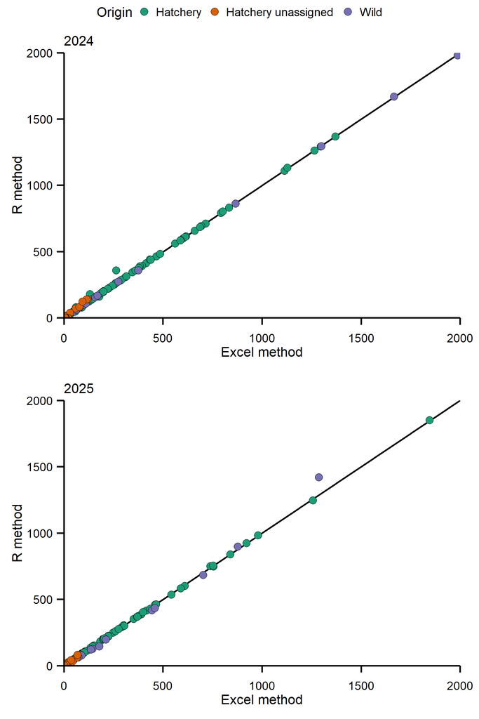

Figure 1: Estimates of Snake River fall Chinook escapement to Lower Granite Dam by age, sex, release group, and origin. Estimates account for fallback and re-ascension and trap outage, including an expansion for the end of the run.

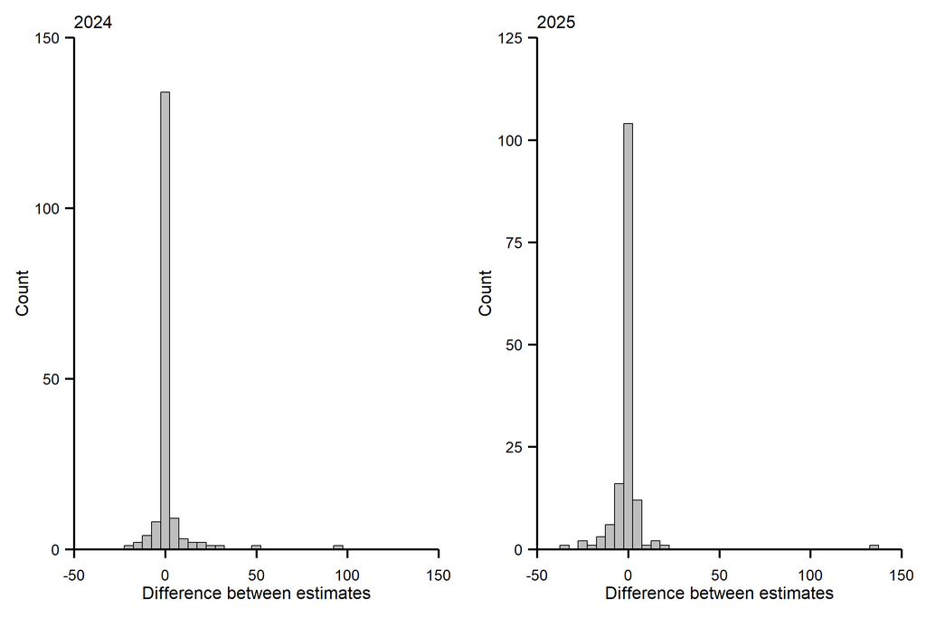

Figure 2: The difference in the estimates of escapement by age, sex, and release group between the original and new method. Estimates account for fallback and re-ascension and trap outage periods.

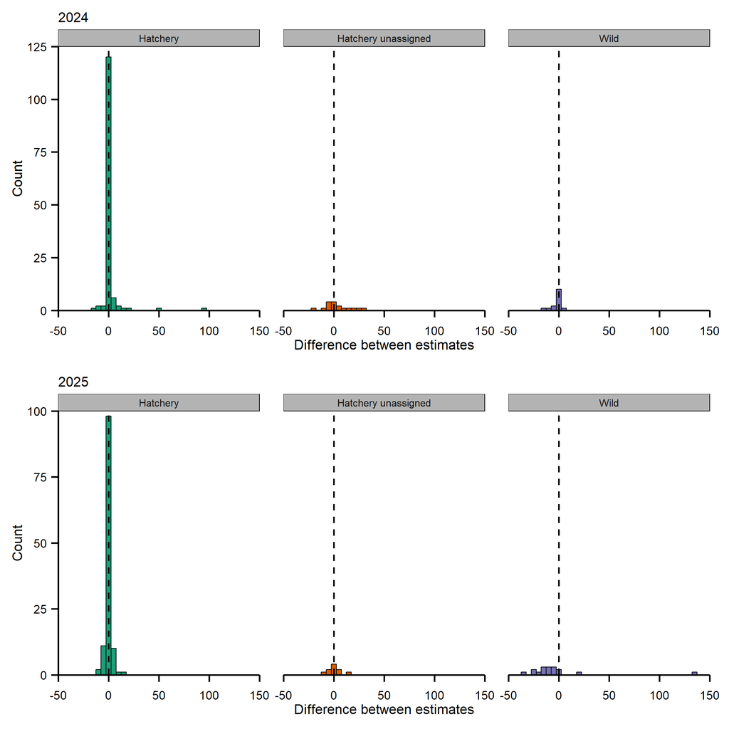

Figure 3: The difference in the estimates of escapement by age, sex, origin, and release group between the original and new method. Estimates account for fallback and re-ascension and trap outage periods.